# Valoracion contingente

Jorge Martelo

27/5/2021

Para el presente caso se quiere determinar el beneficio económico que 119 turistas le asignan al servicio ambiental que ofrece la playa de Charcas, ubicada en el Centro Poblado de Titilaca, distrito de Platería, provincia de Puno en el periodo 2018. La recoleccion de informacion se realizo preguntandole al encuestado sobre su disposición a pagar (DAP) por la mejora en la calidad del bien ecosistémico. Adicionalmente, con el fin de obtener mejores resultados, se utilizo el formato doble límite que a comparación del formato referéndum, se incorpora una segunda pregunta en función a la respuesta sobre DAP inicial del encuestado.

#### 1 Cargar la base de datos con el nombre VC

```r
library(readxl)
VC <- read_excel("C:/Users/marteloa.5/Google Drive/Teleperformance/Sesiones de R/Valoracion contingente/Basede datos_VC_Playa charcas.xlsx")
```

Los nombres de las variablles son los siguientes:

- **PROBSI**: Respuesta sobre si tiene disponibilidad a pagar
- **PH**: Valor hipotetico a pagar en soles
- **PMAX**: Valor hipotetico maximo a pagar en soles
- **PMIN**: Valor hipotetico minimo a pagar en soles
- **ING**: Ingreso promedio familiar (1:menos de 930 soles, 2: entre 931 y 2100 y 3: mas de 2101 soles )
- **EDAD**: Edad del entrevistado
- **NE**: Nivel educativo en años de estudio
- **TH**: Tamaño del hogar
- **GEN**: Genero (1: hombre, 0: Mujer)
- **SL**: Situacion laboral (1: Desempleado, 2: Jubilado, 3: Estudiante, 4:Trabajador)
- **NV**: Numero de visitas a la playa en los ultimos 12 meses
- **GEN**: Genero (1: hombre, 0: Mujer)
- **PA**: Percepcion ambiental de la playa (1:Contaminacion de lago, 2:Malos olores, 3:Acumulacion de basura, 4:Mal aspecto visual)
- **SAT**:Nivel de satasifaccion por la visita (1:Totalmente satisfecho, 5: Totalmente insatisfecho)

```r
#VC$PROBSI <- as.factor(VC$PROBSI)
#VC$ING <- factor(VC$ING, levels = c(1, 2, 3), ordered = TRUE)
#VC$GEN <- as.factor(VC$GEN)
#VC$SL <- as.factor(VC$SL)
#VC$SAT <- factor(VC$SAT, levels = c(5, 4, 3, 2, 1), ordered = TRUE)
```

#### 2. Realizar un analisis descriptivo de las variables. Identifique la variable respuesta a modelar, cual es tipo de variable?

```r
summary(VC)
```

```
##      PROBSI             PH             PMAX            PMIN
##  Min.   :0.0000   Min.   :2.000   Min.   :2.500   Min.   :1.500
##  1st Qu.:0.0000   1st Qu.:2.750   1st Qu.:3.250   1st Qu.:2.250
##  Median :1.0000   Median :4.000   Median :4.500   Median :3.500
##  Mean   :0.5798   Mean   :3.752   Mean   :4.252   Mean   :3.252
##  3rd Qu.:1.0000   3rd Qu.:4.750   3rd Qu.:5.250   3rd Qu.:4.250
##  Max.   :1.0000   Max.   :5.500   Max.   :6.000   Max.   :5.000
##       DYY              DYN              DNY              DNN
##  Min.   :0.0000   Min.   :0.0000   Min.   :0.0000   Min.   :0.0000
##  1st Qu.:0.0000   1st Qu.:0.0000   1st Qu.:0.0000   1st Qu.:0.0000
##  Median :0.0000   Median :0.0000   Median :0.0000   Median :0.0000
##  Mean   :0.3529   Mean   :0.2269   Mean   :0.2017   Mean   :0.2185
##  3rd Qu.:1.0000   3rd Qu.:0.0000   3rd Qu.:0.0000   3rd Qu.:0.0000
##  Max.   :1.0000   Max.   :1.0000   Max.   :1.0000   Max.   :1.0000
##       ING             EDAD             NE              TH
##  Min.   :1.000   Min.   :21.00   Min.   : 8.00   Min.   :1.000
##  1st Qu.:1.000   1st Qu.:35.00   1st Qu.:12.50   1st Qu.:3.000
##  Median :1.000   Median :41.00   Median :16.00   Median :4.000
##  Mean   :1.681   Mean   :43.38   Mean   :15.03   Mean   :3.849
##  3rd Qu.:2.000   3rd Qu.:50.00   3rd Qu.:18.00   3rd Qu.:4.000
##  Max.   :3.000   Max.   :70.00   Max.   :22.00   Max.   :7.000
##       GEN               SL              NV               PA
##  Min.   :0.0000   Min.   :1.000   Min.   : 1.000   Min.   :1.000
##  1st Qu.:0.0000   1st Qu.:1.000   1st Qu.: 1.000   1st Qu.:3.000
##  Median :1.0000   Median :4.000   Median : 1.000   Median :3.000
##  Mean   :0.5714   Mean   :3.067   Mean   : 1.395   Mean   :2.706
##  3rd Qu.:1.0000   3rd Qu.:4.000   3rd Qu.: 1.000   3rd Qu.:3.000
##  Max.   :1.0000   Max.   :4.000   Max.   :10.000   Max.   :4.000
##       SAT
##  Min.   :1.000
##  1st Qu.:2.000
##  Median :2.000
##  Mean   :2.277
##  3rd Qu.:3.000
##  Max.   :5.000
```

#### 3. Graficar el efecto de los aumentos de precios hipoteticos sobre la disponibilidad a . Que conclusion puede llegar?

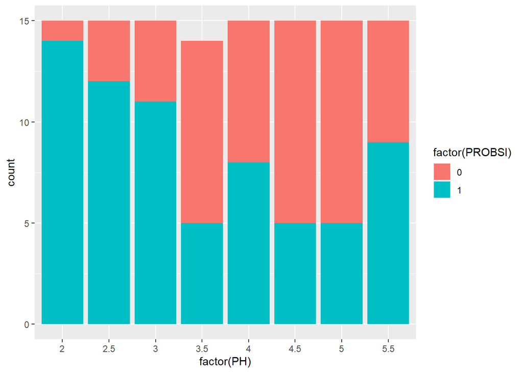

```r
library(ggplot2)
ggplot(VC)+
  aes(x = factor(PH), fill = factor(PROBSI))+
  geom_bar()
```

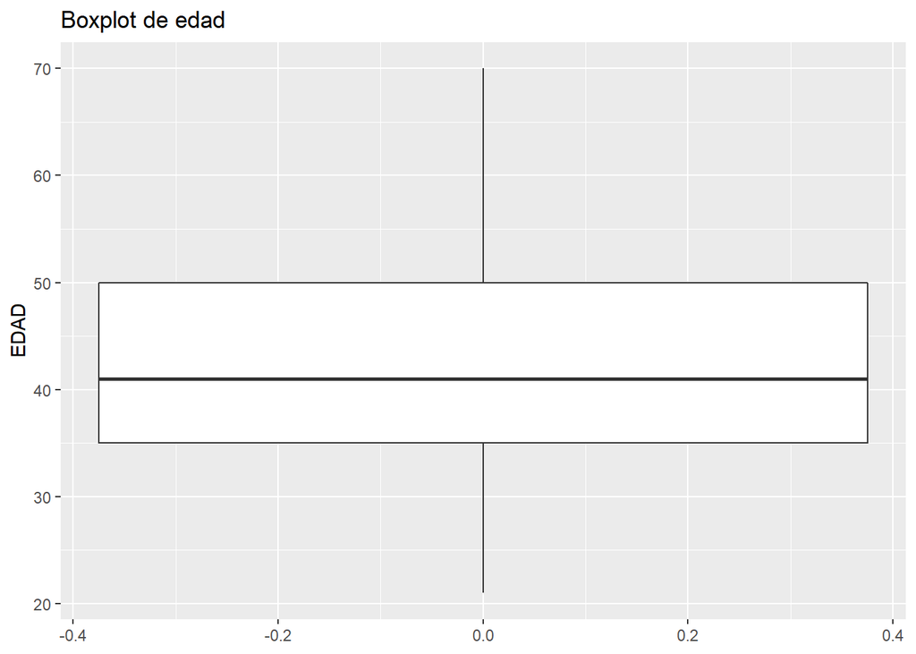

[output not shown]

```r
ggplot(VC)+
  aes(y = EDAD)+
  geom_boxplot()+
  ggtitle("Boxplot de edad")
```

De acuerdo a la naturaleza de la variable respuesta, para el caso del calculo de la disponibilidad a pagar debemos utilizar la familia de modelos logit o probit. Ambos modelos funcionan para estimar la probabilidad de ocurrencia de un evento, en este caso si una persona tiene o no disponibilidad a pagar (DAP) sobre una mejora de un bien ambiental.

**Estimacion modelo tipo referendum (SBCV)**

*Modelo Probit* Mas allá de la estimacion de las probabilidades, lo interesante del modelo Probit es la estimacion de la DAP media de los individuos encuestados (muestra), dicha estimacion parte de la siguiente expresion:

$$ln(\frac{p}{1-p}) = \alpha + \hat{\beta_1}BID + e$$
$$0 = \alpha + \hat{\beta_1}BID + e$$

$$BID = DAP = \frac{-\alpha}{\hat{\beta_1}}$$

En donde $\alpha$ es el intercepto del modelo y $\hat{\beta}$ representa el coeficiente estimado para el valor hipotetico a pagar (BID).

#### 5. Estime el modelo probit con todas las variables de la base de datos. Interprete el coeficiente de la variable precio hipotetico. Que variables no son significantes?

```r
probit <- glm(data = VC[,-c(3:8)],
              PROBSI ~.,
              family = binomial("probit"))
summary(probit)
```

```
##
## Call:
## glm(formula = PROBSI ~ ., family = binomial("probit"), data = VC[,
##     -c(3:8)])
##
## Deviance Residuals:
##      Min        1Q    Median        3Q       Max
## -2.24233  -0.05229   0.00001   0.04837   1.89822
##
## Coefficients:
##             Estimate Std. Error z value Pr(>|z|)
## (Intercept) -5.82655    3.02775  -1.924 0.054307 .
## PH          -1.41845    0.37517  -3.781 0.000156 ***
## ING          3.07560    0.72769   4.227 2.37e-05 ***
## EDAD        -0.00691    0.02408  -0.287 0.774145
## NE           0.28745    0.09977   2.881 0.003963 **
## TH           0.52124    0.20619   2.528 0.011472 *
## GEN          0.39999    0.52395   0.763 0.445214
## SL           0.42169    0.20825   2.025 0.042870 *
## NV           0.16881    0.16750   1.008 0.313541
## PA          -0.35793    0.41508  -0.862 0.388511
## SAT          0.08145    0.34277   0.238 0.812180
## ---
## Signif. codes:  0 '***' 0.001 '**' 0.01 '*' 0.05 '.' 0.1 ' ' 1
##
## (Dispersion parameter for binomial family taken to be 1)
##
##     Null deviance: 161.922  on 118  degrees of freedom
## Residual deviance:  37.324  on 108  degrees of freedom
## AIC: 59.324
##
## Number of Fisher Scoring iterations: 10
```

#### 6. Estime el mejor modelo probit unicamente con las variables significativas. Compare el nuevo modelo con el anteriormente estimado, cual es mejor? por que?.

```r
#Nuevo modelo
probit <- glm(data = VC[,-c(3:8)],
              PROBSI ~ PH + ING + NE + TH + SL,
              family = binomial("probit"))
summary(probit)
```

```
##
## Call:
## glm(formula = PROBSI ~ PH + ING + NE + TH + SL, family = binomial("probit"),
##     data = VC[, -c(3:8)])
##
## Deviance Residuals:
##      Min        1Q    Median        3Q       Max
## -2.35559  -0.06455   0.00009   0.06544   1.88917
##
## Coefficients:
##             Estimate Std. Error z value Pr(>|z|)
## (Intercept) -5.98762    1.79987  -3.327 0.000879 ***
## PH          -1.33060    0.33444  -3.979 6.93e-05 ***
## ING          2.86951    0.64321   4.461 8.15e-06 ***
## NE           0.27164    0.08304   3.271 0.001071 **
## TH           0.48087    0.18390   2.615 0.008925 **
## SL           0.36850    0.17380   2.120 0.033987 *
## ---
## Signif. codes:  0 '***' 0.001 '**' 0.01 '*' 0.05 '.' 0.1 ' ' 1
##
## (Dispersion parameter for binomial family taken to be 1)
##
##     Null deviance: 161.92  on 118  degrees of freedom
## Residual deviance:  39.94  on 113  degrees of freedom
## AIC: 51.94
##
## Number of Fisher Scoring iterations: 9
```

#### 7. Teniendo en cuenta el modelo obtenido, calcule la DAP

```r
# Calculo de DAP
MediaIng <- mean(VC$ING)
MediaNE <- mean(VC$NE)
MediaTH <- mean(VC$TH)
MediaSL <- mean(VC$SL)

-(5.98762+(2.86951*MediaIng)+(0.27164*MediaNE)+(0.48087*MediaTH)+(0.36850*MediaSL))/-1.33060
```

```
## [1] 13.43384
```

$$DAP = \frac{-1}{\hat{\beta}}ln(1 + e^{\alpha})$$
En donde $\beta$ es el coeficiente estimado para el precio y $\alpha$ el intercepto.

#### 8. Estime el modelo LOGIT completo y comparelo con el primer modelo PROBIT. Existen diferencias? cual es mejor y por que ?

```r
probit <- glm(data = VC[,-c(3:8)],
              PROBSI ~ .,
              family = binomial("logit"))
summary(probit)
```

```
##
## Call:
## glm(formula = PROBSI ~ ., family = binomial("logit"), data = VC[,
##     -c(3:8)])
##
## Deviance Residuals:
##      Min        1Q    Median        3Q       Max
## -2.38268  -0.09733   0.00429   0.09303   1.85909
##
## Coefficients:
##              Estimate Std. Error z value Pr(>|z|)
## (Intercept) -10.15323    5.69768  -1.782 0.074750 .
## PH           -2.57101    0.73648  -3.491 0.000481 ***
## ING           5.45623    1.41821   3.847 0.000119 ***
## EDAD         -0.01371    0.04518  -0.303 0.761648
## NE            0.53210    0.19107   2.785 0.005356 **
## TH            0.94891    0.38117   2.489 0.012794 *
## GEN           0.69795    0.95097   0.734 0.462985
## SL            0.71309    0.38196   1.867 0.061914 .
## NV            0.31807    0.30191   1.054 0.292110
## PA           -0.66396    0.78767  -0.843 0.399261
## SAT           0.08201    0.62152   0.132 0.895029
## ---
## Signif. codes:  0 '***' 0.001 '**' 0.01 '*' 0.05 '.' 0.1 ' ' 1
##
## (Dispersion parameter for binomial family taken to be 1)
##
##     Null deviance: 161.922  on 118  degrees of freedom
## Residual deviance:  37.858  on 108  degrees of freedom
## AIC: 59.858
##
## Number of Fisher Scoring iterations: 8
```

#### 9. Estime el mejor modelo logit unicamente con las variables significativas. Compare el nuevo modelo con el mejor PROBIT y con el LOGIT completo, cual es mejor? por que?

```r
logit <- glm(data = VC[,-c(3:8)],
              PROBSI ~ PH + ING + NE + TH + SL,
              family = binomial("logit"))
summary(logit)
```

```
##
## Call:
## glm(formula = PROBSI ~ PH + ING + NE + TH + SL, family = binomial("logit"),
##     data = VC[, -c(3:8)])
##
## Deviance Residuals:
##      Min        1Q    Median        3Q       Max
## -2.46904  -0.11161   0.00772   0.11052   1.86146
##
## Coefficients:
##             Estimate Std. Error z value Pr(>|z|)
## (Intercept) -11.1144     3.4615  -3.211 0.001323 **
## PH           -2.3384     0.6360  -3.676 0.000236 ***
## ING           5.1311     1.2523   4.097 4.18e-05 ***
## NE            0.5071     0.1612   3.146 0.001653 **
## TH            0.8648     0.3363   2.571 0.010127 *
## SL            0.6510     0.3134   2.077 0.037806 *
## ---
## Signif. codes:  0 '***' 0.001 '**' 0.01 '*' 0.05 '.' 0.1 ' ' 1
##
## (Dispersion parameter for binomial family taken to be 1)
##
##     Null deviance: 161.922  on 118  degrees of freedom
## Residual deviance:  40.353  on 113  degrees of freedom
## AIC: 52.353
##
## Number of Fisher Scoring iterations: 8
```

#### 10. De acuerdo a los coeficientes del modelo LOGIT, calcule la DAP mediana y la DAP promedio

```r
MediaIng <- mean(VC$ING)
MediaNE <- mean(VC$NE)
MediaTH <- mean(VC$TH)
MediaSL <- mean(VC$SL)
-(-11.1144 + (5.1311*MediaIng) + (0.5071*MediaNE) + (0.8648*MediaTH) + (0.6510*MediaSL))/-2.3384
```

```
## [1] 4.472288
```

```r
(-1/-2.3384)*log(1+exp(-11.1144 + (5.1311*MediaIng) + (0.5071*MediaNE) + (0.8648*MediaTH) + (0.6510*MediaSL)))
```

```
## [1] 4.4723
```

Debido a que R es una plataforma open source en donde cualquier investigador puede compartir sus algoritmos con terceros, recientemente se creo un paquete especifico para la estimacion de DAP a través de metodologias de valoracion contingente:

#### 11. Instale el paquete DCChhoice

```r
#install.packages("icens",
#                 repos = c("http://www.bioconductor.org/packages/release/bioc",
#                           "https://cran.rstudio.com/"),
#                 dep = TRUE)

#if (!requireNamespace("BiocManager", quietly = TRUE))
#  install.packages("BiocManager")
```

#### 12. Estime un modelo de regresion con respuesta tipo referendum con la funcion de enlace logit utilizando las variables significativas. Compare los coeficientes, signos, AIC y DAP del nuevo modelo con los valores del modelo estimado previamente a través de la funcion GLM. Que diferencias existen?

```r
library(DCchoice)
ModelN <- sbchoice(data = VC[,-c(3:8)],
                   PROBSI ~ ING + NE + TH + SL|PH,
                   dist = "logistic")
summary(ModelN)
```

```
##
## Call:
## sbchoice(formula = PROBSI ~ ING + NE + TH + SL | PH, data = VC[, -c(3:8)],
##     dist = "logistic")
##
## Formula:
## PROBSI ~ ING + NE + TH + SL | PH
##
## Coefficients:
##             Estimate Std. Error z value Pr(>|z|)
## (Intercept) -11.1144     3.4615  -3.211 0.001323 **
## ING           5.1311     1.2523   4.097 4.18e-05 ***
## NE            0.5071     0.1612   3.146 0.001653 **
## TH            0.8648     0.3363   2.571 0.010127 *
## SL            0.6510     0.3134   2.077 0.037806 *
## BID          -2.3384     0.6360  -3.676 0.000236 ***
## ---
## Signif. codes:  0 '***' 0.001 '**' 0.01 '*' 0.05 '.' 0.1 ' ' 1
##
## Distribution: logistic
## Number of Obs.: 119
## log-likelihood: -20.17659
## pseudo-R^2: 0.7508 , adjusted pseudo-R^2: 0.6767
## LR statistic: 121.569 on 5 DF, p-value: 0.000
## AIC: 52.353185 , BIC: 69.027926
##
## Iterations: 8
## Convergence: TRUE
##
## WTP estimates:
##  Mean : 4.472506
##  Mean : 4.435467 (truncated at the maximum bid)
##  Mean : 4.836761 (truncated at the maximum bid with adjustment)
##  Median : 4.472494
```

#### 13. Estime los intervalos de confianza de la disponibilidad a pagar utilizando el metodo boostrap. Adicionalmente grafique la disponibilidad a pagar en funcion del modelo estimado, que puede inferir?

```r
# Intervalo de confianza
bootCI(ModelN)
```

```
## the bootstrap confidence intervals
##                         Estimate     LB         UB
## Mean                      4.4725 0.0000     7.5410
## truncated Mean            4.4355 0.0000     5.4998
## adjusted truncated Mean   4.8368 0.0000 10464.3511
## Median                    4.4725 0.0000     7.5410
```

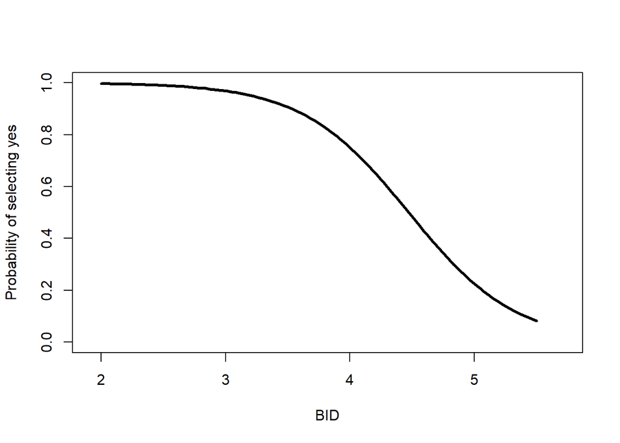

```r
# Grafico WTP
plot(ModelN)
```

**Estimacion modelo tipo doble limite (DBCV)**

La metodologia doble limite aplica una segunda pregunta al encuesta en funcion de su primera respuesta, es decir, en caso de que la persona haya respondido positivamente a la disponibilidad a pagar por X cantidad de dinero, el encuestador procederá a indagar por segunda vez su disponibilidad a pagar realizando un incremento en dicha cantidad.

Por otro lado, en caso de que la persona haya repsondido negativamente a la primera pregunta, el encuestador volverá a indagar sobre su DAP por un monto menor al de la primera pregunta. De acuerdo a esto, se pueden codificar las respuestas de la siguiente manera:

- YY: DAP afirmativa en primera y segunda pregunta
- YN: DAP afirmativa en la primera pregunta y negativa en la segunda
- NY: DAP negativa en la primera pregunda y afirmativa en la segunda
- NN: DAP negativa en primera y segunda pregunta

#### 14. Crear la segunda respuesta de disponibilidad a pagar como variable

```r
VC$PROBSI2 <- ifelse(VC$DYY == 1 | VC$DNY == 1, 1, 0)
VC$PH2 <- ifelse(VC$PROBSI == 1, VC$PMAX, VC$PMIN)
```

#### 15. Estimar el modelo logistico de doble limite con todas las variables. Existen cambios frente al primer modelo logistico estimado?

```r
ModelDB <- dbchoice(data = VC[,-c(3:8)],
                   PROBSI + PROBSI2 ~ ING + EDAD + NE + TH + GEN + SL + NV + PA + SAT|PH + PH2,
                   dist = "logistic")
summary(ModelDB)
```

```
##
## Call:
## dbchoice(formula = PROBSI + PROBSI2 ~ ING + EDAD + NE + TH + GEN + SL +
##     NV + PA + SAT | PH + PH2, data = VC[, -c(3:8)], dist = "logistic")
##
## Formula:
## PROBSI + PROBSI2 ~ ING + EDAD + NE + TH + GEN + SL + NV + PA + SAT |
##     PH + PH2
##
## Coefficients:
##              Estimate Std. Error z value  Pr(>|z|)
## (Intercept) -0.892484   1.873086 -0.4765  0.633734
## ING          1.141141   0.283088  4.0310   5.6e-05 ***
## EDAD        -0.002735   0.018934 -0.1444  0.885157
## NE           0.156025   0.052396  2.9778  0.002903 **
## TH           0.241608   0.149123  1.6202  0.105190
## GEN          0.338986   0.399506  0.8485  0.396152
## SL           0.267256   0.147489  1.8120  0.069979 .
## NV           0.083718   0.122905  0.6812  0.495768
## PA           0.073454   0.243164  0.3021  0.762595
## SAT          0.262268   0.263046  0.9970  0.318743
## BID         -1.481515   0.159622 -9.2814 < 2.2e-16 ***
## ---
## Signif. codes:  0 '***' 0.001 '**' 0.01 '*' 0.05 '.' 0.1 ' ' 1
##
## Distribution: logistic
## Number of Obs.: 119
## Log-likelihood: -148.541979
##
## LR statistic: 48.280 on 9 DF, p-value: 0.000
## AIC: 319.083957 , BIC: 349.654316
##
## Iterations: 66 18
## Convergence: TRUE
##
## WTP estimates:
##  Mean : 4.124664
##  Mean : 4.084059 (truncated at the maximum bid)
##  Mean : 4.337286 (truncated at the maximum bid with adjustment)
##  Median: 4.123165
```

#### 16. Estimar el mejor modelo excluyendo las variables no significativas. Interprete la DAP, presenta cambios significativos con respecto al modelo anterior?

```r
ModelDB <- dbchoice(data = VC[,-c(3:8)],
                   PROBSI + PROBSI2 ~ ING + NE + SL |PH + PH2,
                   dist = "logistic")
summary(ModelDB)
```

```
##
## Call:
## dbchoice(formula = PROBSI + PROBSI2 ~ ING + NE + SL | PH + PH2, data = VC[,
##     -c(3:8)], dist = "logistic")
##
## Formula:
## PROBSI + PROBSI2 ~ ING + NE + SL | PH + PH2
##
## Coefficients:
##             Estimate Std. Error z value  Pr(>|z|)
## (Intercept)  0.81862    0.88715  0.9227  0.356139
## ING          1.14714    0.26486  4.3310   1.5e-05 ***
## NE           0.15034    0.04919  3.0559  0.002244 **
## SL           0.28686    0.14113  2.0326  0.042097 *
## BID         -1.43010    0.15275 -9.3625 < 2.2e-16 ***
## ---
## Signif. codes:  0 '***' 0.001 '**' 0.01 '*' 0.05 '.' 0.1 ' ' 1
##
## Distribution: logistic
## Number of Obs.: 119
## Log-likelihood: -150.897305
##
## LR statistic: 43.569 on 3 DF, p-value: 0.000
## AIC: 311.794609 , BIC: 325.690227
##
## Iterations: 37 10
## Convergence: TRUE
##
## WTP estimates:
##  Mean : 4.1181
##  Mean : 4.072357 (truncated at the maximum bid)
##  Mean : 4.347667 (truncated at the maximum bid with adjustment)
##  Median: 4.116161
```

#### 17. Calcule los intervalos de confianza para la DAP con el metodo boostrap, ¿que diferencias presenta con respecto a los intevalos del modelo con respuest referendo?. FInalmente grafique la probabilidad de la DAP en funcion del precio hipotetico (BID)

```r
bootCI(ModelDB)
```

```
## the bootstrap confidence intervals
##                         Estimate     LB     UB
## Mean                      4.1181 3.7994 4.4262
## truncated Mean            4.0724 3.7654 4.3605
## adjusted truncated Mean   4.3477 3.9353 4.8059
## Median                    4.1162 3.7959 4.4250
```

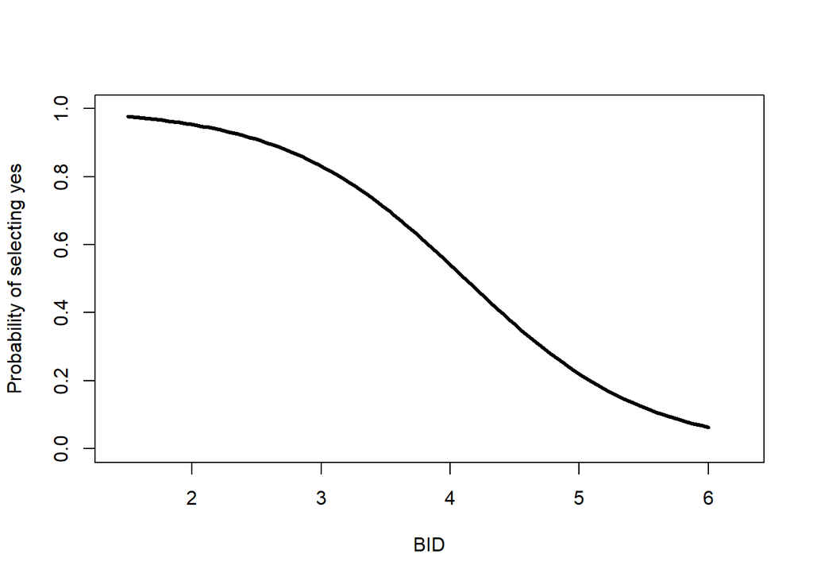

```r
plot(ModelDB)
```

#### 18. Predecir la probabilidad de que una persona tenga disponibilidad a pagar un precio hipotetico de US 3 dadas las siguientes caracteristicas:

- Ingreso: 2
- Nivel educativo 11
- Situacion laboral 3

```r
predict(ModelDB, newdata = data.frame(ING = 2, NE = 11, SL = 3, PH = 3), type = "probability")
```

```
## [1] 0.7919724
```